# dispRity model test

Mark Puttick and Thomas Guillerme

2018-07-19

# Introduction

Changes in patterns in disparity through time are of key interest in macroevolution. By analysing patterns of disparity in groups of taxa we can understand aspects of their tempo and mode evolution, patterns of innovation, and responses to environmental or biotic change.

This vignette will detail the use of the functions `model.test` and `model.test.wrapper` in the R package `dispRity` to fit competing models that describe changes in disparity through time.

As input `model.test` takes disparity data that are placed into time bins, and then the relative fit of models that describe disparity changes across all bins are compared. Models can evaluate whether disparity remains largely constant through time, fluctuates randomly, follows a trend, or if changes in disparity slow through time. Additionally, more than one mode of change can be fit to the data, so at a certain time(s) there is a distinct shift to a new mode. This can be used to test if disparity changes dramatically following an event such as a mass extinction, and the model also allows for testing of multiple shift points with no *a priori* expectations.

The code used for these models is based on those developed by Gene Hunt (Hunt 2006; Hunt 2012; Hunt, Hopkins, and Lidgard 2015). So we acknowledge and thank Gene Hunt for developing these models and writing the original R code that served as inspiration for these models.

## `dispRity`

This vignette uses the [dispRity package](https://cran.r-project.org/web/packages/dispRity/index.html) in R (Guillerme 2018). For a more general introduction to the package please see this guide to [dispRity](https://rawgit.com/TGuillerme/dispRity/master/inst/gitbook/_book/index.html) written by Thomas Guillerme and Natalie Cooper.

This code is only available in the `dispRity` package version `1.2` or higher. Make sure the right version is installed by checking it either from the CRAN:

```r
## Installing the CRAN version of dispRity
install.packages("dispRity")
library(dispRity)

## Is the version 1.2 or higher?
packageVersion("dispRity")
```

Or from GitHub to have the latest released version:

```r
## Checking if devtools is already installed
if(!require(devtools)) install.packages("devtools")

## Installing the GitHub version of dispRity
install_github("TGuillerme/dispRity", ref = "release")
library(dispRity)

## Is the version 1.2 or higher?
packageVersion("dispRity")
```

# Fitting modes of evolution to disparity data

## Input data format

```r
data(BeckLee_disparity)
BeckLee_disparity
```

```
##  ---- dispRity object ----
## 121 continuous (proximity) time subsets for 99 elements with 97 dimensions:
##      120, 119, 118, 117, 116 ...
## Data was bootstrapped 100 times (method:"full").
## Disparity was calculated as: c(sum, variances).
```

However, it is likely your data will not be in this format. Specifically, the object `BeckLee_disparity` data were constructed using a tree of 50 taxa (`BeckLee_tree`), an ordinated matrix of tip and internal node states (`BeckLee_mat99`), and the ages of fossil tip (`BeckLee_ages`) - your data may be in a similar format.

The following code is not necessary to be run and is just given as an example:

```r
## Loading the ordinated matrix
data(BeckLee_mat99)

## Loading the temporal data
data(BeckLee_ages)

## Loading the tree
data(BeckLee_tree)

## Creating gradual split subsets
continuous_data <- chrono.subsets(BeckLee_mat99, BeckLee_tree, method = "continuous",
                                 time = seq(120, 0, length.out = 120), model = "gradual.split")

## Bootstrapping the data
continuous_data_bootstrap <- boot.matrix(continuous_data)

## Measuring disparity
BeckLee_disparity <- dispRity(continuous_data_bootstrap, c(sum, variances))
```

For input into `model.test` we will call these data from `dispRity`, and then place them into 120 bins of 1 million year duration, bootstrap these data, and then calculate are disparity metric - the sum of variances.

```r
model_data <- BeckLee_disparity
```

We now have our disparity data to examine trends through time!

## Simple modes of disparity change through time

### `model.test`

Changes in disparity-through-time can follow a range of models, such as random walks, stasis, constrained evolution, trends, or an early burst model of evolution. We will start with by fitting the simplest modes of evolution to our data. For example we may have a null expectation of time-invariant change in disparity in which values fluctuate with a variance around the mean - this would be best describe by a Stasis model:

```r
disp_time <- model.test(data = model_data, model = "Stasis")
```

```
## Evidence of equal variance (Bartlett's test of equal variances p = 0).
## Variance is not pooled.
## Running Stasis model...Done. Log-likelihood = -59.501
```

We can see the standard output from `model.test`. The first output message tells us it has tested for equal variances in each sample. The model uses Bartlett’s test of equal variances to assess if variances are equal, so if p > 0.05 then variance is treated as the same for all samples, but if (p < 0.05) then each bin variance is unique. Here we have p < 0.05, so variance is not pooled between samples.

By default `model.test` will use Bartlett’s test to assess for homogeneity of variances, and then use this to decide to pool variances or not. This is ignored if the argument `pool.variance` in `model.test` is changed from the default `NULL` to `TRUE` or `FALSE`. For example, to ignore Bartlett’s test and pool variances manually we would do the following:

```r
disp_time_pooled <- model.test(data = model_data, model = "Stasis", pool.variance = TRUE)
```

```
## Running Stasis model...Done. Log-likelihood = -58.233
```

However, unless you have good reason to choose otherwise it is recommended to use the default of `pool.variance = NULL`:

```r
disp_time <- model.test(data = model_data, model = "Stasis", pool.variance = NULL)
```

```
## Evidence of equal variance (Bartlett's test of equal variances p = 0).
## Variance is not pooled.
## Running Stasis model...Done. Log-likelihood = -59.501
```

```r
disp_time
```

```
## Disparity evolution model fitting:
## Call: model.test(data = model_data, model = "Stasis", pool.variance = NULL)
##
##            aicc delta_aicc weight_aicc
## Stasis 123.1027          0           1
##
## Use x$full.details for displaying the models details
## or summary(x) for summarising them.
```

The remaining output gives us the log-likelihood of the Stasis model of -59.501 (you may notice this change when we pooled variances above). The output also gives us the small sample Akaike Information Criterion (AICc), the delta AICc (the distance from the best fitting model), and the AICc weights (~the relative support of this model compared to all models, scaled to one).

These are all metrics of relative fit, so when we test a single model they are not useful. By using the function summary in `dispRity` we can see the maximum likelihood estimates of the model parameters:

```r
summary(disp_time)
```

```
##         aicc delta_aicc weight_aicc log.lik param theta.1 omega
## Stasis 123.1          0           1   -59.5     2     3.4   0.1
```

The `model.test` function is designed to test relative model fit, so we need to test more than one model to make relative comparisons. So let’s compare to the fit of the Stasis model to another model with two parameters: the Brownian motion. Brownian motion assumes a constant mean that is equal to the ancestral estimate of the sequence, and the variance around this mean increases linearly with time. The easier way to compare these models is to simply add `"BM"` to the `models` vector argument:

```r
disp_time <- model.test(data = model_data, model = c("Stasis", "BM"))
```

```
## Evidence of equal variance (Bartlett's test of equal variances p = 0).
## Variance is not pooled.
## Running Stasis model...Done. Log-likelihood = -59.501
## Running BM model...Done. Log-likelihood = 123.938
```

```r
disp_time
```

```
## Disparity evolution model fitting:
## Call: model.test(data = model_data, model = c("Stasis", "BM"))
##
##             aicc delta_aicc  weight_aicc
## Stasis  123.1027   366.8774 2.155677e-80
## BM     -243.7747     0.0000 1.000000e+00
##
## Use x$full.details for displaying the models details
## or summary(x) for summarising them.
```

Et voilà! Here we can see by the log-likelihood, AICc, delta AICc, and AICc weight Brownian motion has a much better relative fit to these data than the Stasis model. Brownian motion has a relative AICc fit 366 units better than Stasis, and virtually has a AICc weight of 1.

We can also all the information about the relative fit of models alongside the maximum likelihood estimates of model parameters using the summary function

```r
summary(disp_time)
```

```
##        aicc delta_aicc weight_aicc log.lik param theta.1 omega
## Stasis  123      366.9           0   -59.5     2   3.403  0.15
## BM     -244        0.0           1   123.9     2      NA    NA
##        ancestral state sigma squared
## Stasis              NA            NA
## BM               2.858         0.003
```

Not that because the parameters per models differ, the summary includes `NA` for inapplicable parameters per models (e.g. the theta and omega parameters from the Stasis models are inapplicable for a Brownian motion model).

We can plot the relative fit of our models using the `plot` function

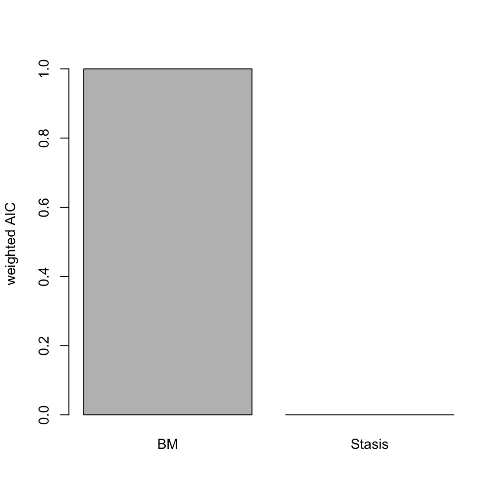

relative fit (AICc weight) of Stasis and Brownian models of disparity through time

```r
plot(disp_time)
```

Here we see and overwhelming support for the Brownian motion model.

Alternatively, we could test all available models single modes: Stasis, Brownian motion, Ornstein-Uhlenbeck (evolution constrained to an optima), Trend (increasing or decreasing mean through time), and Early Burst (exponentially decreasing rate through time)

```r
disp_time <- model.test(data = model_data, model = c("Stasis", "BM", "OU", "Trend", "EB"))
```

```
## Evidence of equal variance (Bartlett's test of equal variances p = 0).
## Variance is not pooled.
## Running Stasis model...Done. Log-likelihood = -59.501
## Running BM model...Done. Log-likelihood = 123.938
## Running OU model...Done. Log-likelihood = 126.431
## Running Trend model...Done. Log-likelihood = 126.361
## Running EB model...Done. Log-likelihood = 113.081
```

```r
summary(disp_time)
```

```
##        aicc delta_aicc weight_aicc log.lik param theta.1 omega
## Stasis  123      369.6       0.000   -59.5     2   3.403  0.15
## BM     -244        2.7       0.157   123.9     2      NA    NA
## OU     -245        2.0       0.227   126.4     4      NA    NA
## Trend  -247        0.0       0.617   126.4     3      NA    NA
## EB     -220       26.6       0.000   113.1     3      NA    NA
##        ancestral state sigma squared alpha optima.1 trend     eb
## Stasis              NA            NA    NA       NA    NA     NA
## BM               2.858         0.003    NA       NA    NA     NA
## OU               2.835         0.002 0.004    5.707    NA     NA
## Trend            2.839         0.002    NA       NA  0.01     NA
## EB               4.055         0.002    NA       NA    NA -0.014
```

These models indicate support for a Trend model, and we can plot the relative support of all model AICc weights

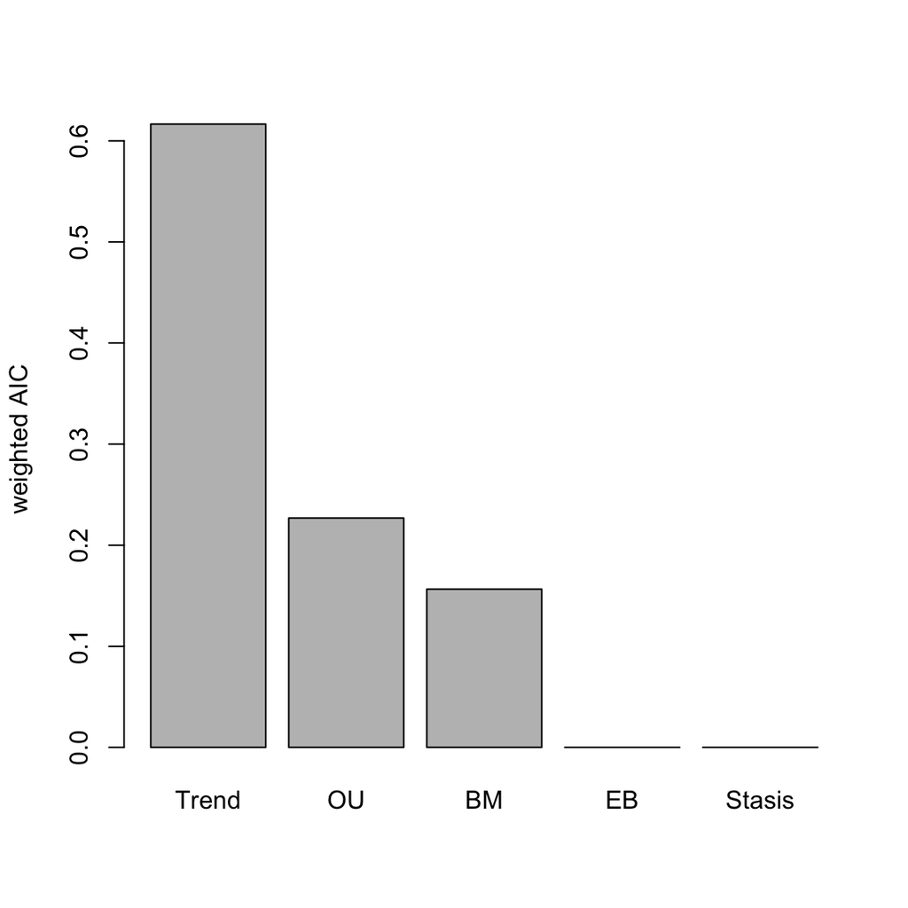

relative fit (AICc weight) of various modes of evolution

```r
plot(disp_time)
```

Is this a trend of increasing or decreasing disparity through time? One way to find out is to look at the summary function for the Trend model:

```r
summary(disp_time)["Trend",]
```

```
##            aicc      delta_aicc     weight_aicc         log.lik
##        -247.000           0.000           0.617         126.400
##           param         theta.1           omega ancestral state
##           3.000              NA              NA           2.839
##   sigma squared           alpha        optima.1           trend
##           0.002              NA              NA           0.010
##              eb
##              NA
```

This show a positive trend (0.01) of increasing disparity through time.

## Plot and run simulation tests in a single step

### `model.test.wrapper`

Patterns of evolution can be fit using `model.test`, but the `model.test.wrapper` fits the same models as `model.test` as well as running predictive tests and plots.

The predictive tests use the maximum likelihood estimates of model parameters to simulate a number of datasets (default = 1000), and analyse whether this is significantly different to the empirical input data using the Rank Envelope test (Murrell 2018). Finally we can plot the empirical data, simulated data, and the Rank Envelope test p values. This can all be done using the function `model.test.wrapper`, and we will set the argument `show.p = TRUE` so *p* values from the Rank Envelope test are printed on the plot:

```r
disp_time <- model.test.wrapper(data = model_data, model = c("Stasis", "BM", "OU", "Trend", "EB"),
                                show.p = TRUE)
```

```
## Evidence of equal variance (Bartlett's test of equal variances p = 0).
## Variance is not pooled.
## Running Stasis model...Done. Log-likelihood = -59.501
## Running BM model...Done. Log-likelihood = 123.938
## Running OU model...Done. Log-likelihood = 126.431
## Running Trend model...Done. Log-likelihood = 126.361
## Running EB model...Done. Log-likelihood = 113.081
```

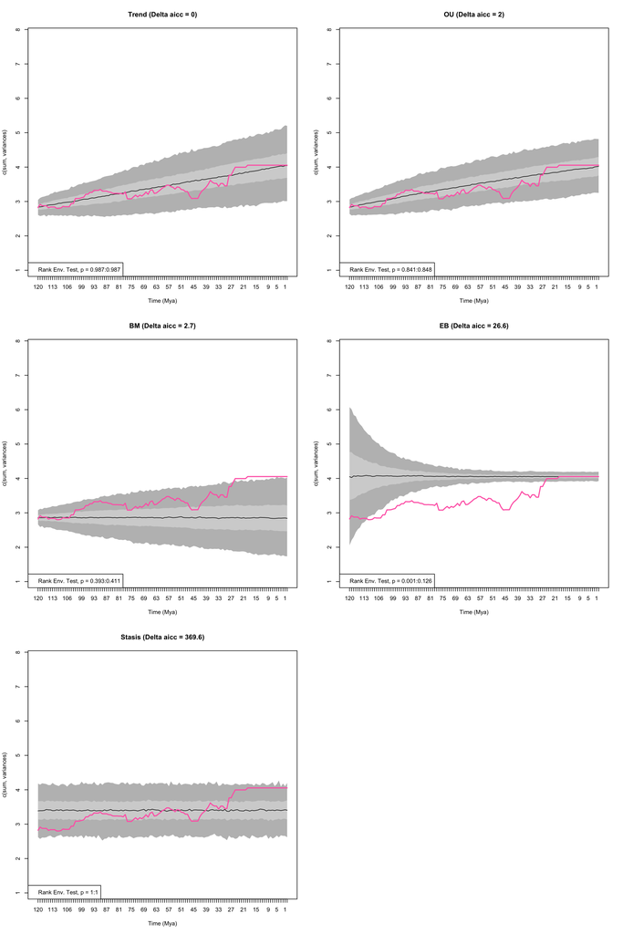

Empirical disparity through time (pink), simulate data based on estimated model parameters (grey), delta AICc, and range of p values from the Rank Envelope test for Trend, OU, BM, EB, and Stasis models

```r
disp_time
```

```
##        aicc delta_aicc weight_aicc log.lik param theta.1 omega
## Trend  -247        0.0       0.617   126.4     3      NA    NA
## OU     -245        2.0       0.227   126.4     4      NA    NA
## BM     -244        2.7       0.157   123.9     2      NA    NA
## EB     -220       26.6       0.000   113.1     3      NA    NA
## Stasis  123      369.6       0.000   -59.5     2   3.403  0.15
##        ancestral state sigma squared alpha optima.1 trend     eb
## Trend            2.839         0.002    NA       NA  0.01     NA
## OU               2.835         0.002 0.004    5.707    NA     NA
## BM               2.858         0.003    NA       NA    NA     NA
## EB               4.055         0.002    NA       NA    NA -0.014
## Stasis              NA            NA    NA       NA    NA     NA
##        median p value lower p value upper p value
## Trend      0.98701299   0.987012987     0.9870130
## OU         0.84465534   0.841158841     0.8481518
## BM         0.40159840   0.392607393     0.4105894
## EB         0.06343656   0.000999001     0.1258741
## Stasis     1.00000000   1.000000000     1.0000000
```

From this plot we can see the empirical estimates of disparity through time (pink) compared to the predictive data based upon the simulations using the estimated parameters from each model. There is no significant differences between the empirical data and simulated data, except for the Early Burst model.

Trend is the best-fitting model but the plot suggests the OU model also follows a trend-like pattern. This is because the optima for the OU model (5.7) is different to the ancestral state 2.835 and outside the observed value. This is potentially unrealistic, and one way to alleviate this issue is to set the optima of the OU model to equal the ancestral estimate - this is the normal practice for OU models in comparative phylogenetics. To set the optima to the ancestral value we change the argument `fixed.optima = TRUE`:

```r
disp_time <- model.test.wrapper(data = model_data, model = c("Stasis", "BM", "OU", "Trend", "EB"),
                                show.p = TRUE, fixed.optima = TRUE)
```

```
## Evidence of equal variance (Bartlett's test of equal variances p = 0).
## Variance is not pooled.
## Running Stasis model...Done. Log-likelihood = -59.501
## Running BM model...Done. Log-likelihood = 123.938
## Running OU model...Done. Log-likelihood = 123.938
## Running Trend model...Done. Log-likelihood = 126.361
## Running EB model...Done. Log-likelihood = 113.081
```

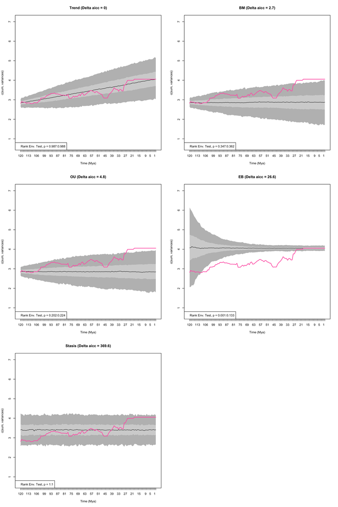

Empirical disparity through time (pink), simulate data based on estimated model parameters (grey), delta AICc, and range of p values from the Rank Envelope test for Trend, OU, BM, EB, and Stasis models with the optima of the OU model set to equal the ancestral value

```r
disp_time
```

```
##        aicc delta_aicc weight_aicc log.lik param theta.1 omega
## Trend  -247        0.0       0.745   126.4     3      NA    NA
## BM     -244        2.7       0.189   123.9     2      NA    NA
## OU     -242        4.8       0.066   123.9     3      NA    NA
## EB     -220       26.6       0.000   113.1     3      NA    NA
## Stasis  123      369.6       0.000   -59.5     2   3.403  0.15
##        ancestral state sigma squared alpha trend     eb median p value
## Trend            2.839         0.002    NA  0.01     NA     0.98751249
## BM               2.858         0.003    NA    NA     NA     0.35414585
## OU               2.858         0.003     0    NA     NA     0.21278721
## EB               4.055         0.002    NA    NA -0.014     0.06693307
## Stasis              NA            NA    NA    NA     NA     1.00000000
##        lower p value upper p value
## Trend    0.987012987     0.9880120
## BM       0.346653347     0.3616384
## OU       0.201798202     0.2237762
## EB       0.000999001     0.1328671
## Stasis   1.000000000     1.0000000
```

The relative fit of the OU model is decreased by constraining the fit of the optima to equal the ancestral state value. In fact as the OU attraction parameter (alpha) is zero, the model is equal to a Brownian motion model but is penalised by having an extra parameter. Note that indeed, the plots of the BM model and the OU model look nearly identical.

## Multiple modes of evolution (time shifts)

As well as fitting a single model to a sequence of disparity values we can also allow for the mode of evolution to shift at a single or multiple points in time. The timing of a shift in mode can be based on an a prior expectation, such as a mass extinction event, or the model can test multiple points to allow to find time shift point with the highest likelihood.

Models can be fit using `model.test` but it can be more convenient to use `model.test.wrapper`. Here we will compare the relative fit of Brownian motion, Trend, Ornstein-Uhlenbeck and a multi-mode Ornstein Uhlenbck model in which the optima changes at 66 million years ago, the Cretaceous-Palaeogene boundary.

For example, we could be testing the hypothesis that the extinction of non-avian dinosaurs allowed mammals to go from scurrying in the undergrowth (low optima/low disparity) to dominating all habitats (high optima/high disparity). We will constrain the optima of OU model in the first time begin (i.e, pre-66 Mya) to equal the ancestral value:

```r
disp_time <- model.test.wrapper(data = model_data, model = c("BM", "Trend", "OU", "multi.OU"),
                                time.split = 66, pool.variance = NULL, show.p = TRUE,
                                fixed.optima = TRUE)
```

```
## Evidence of equal variance (Bartlett's test of equal variances p = 0).
## Variance is not pooled.
## Running BM model...Done. Log-likelihood = 123.938
## Running Trend model...Done. Log-likelihood = 126.361
## Running OU model...Done. Log-likelihood = 123.938
## Running multi.OU model...Done. Log-likelihood = 126.469
```

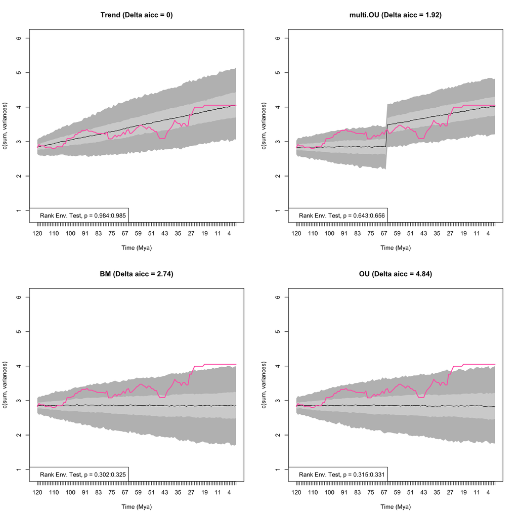

Empirical disparity through time (pink), simulate data based on estimated model parameters (grey), delta AICc, and range of p values from the Rank Envelope test for BM, Trend, OU, and multi OU models with a shift in optima allowed at 66 Ma

```r
disp_time
```

```
##          aicc delta_aicc weight_aicc log.lik param ancestral state
## Trend    -247      0.000       0.580   126.4     3           2.839
## multi.OU -245      1.922       0.222   126.5     4           2.836
## BM       -244      2.742       0.147   123.9     2           2.858
## OU       -242      4.845       0.051   123.9     3           2.858
##          sigma squared trend alpha optima.2 median p value lower p value
## Trend            0.002  0.01    NA       NA      0.9845155     0.9840160
## multi.OU         0.002    NA 0.005    5.526      0.6498501     0.6433566
## BM               0.003    NA    NA       NA      0.3131868     0.3016983
## OU               0.003    NA 0.000       NA      0.3226773     0.3146853
##          upper p value
## Trend        0.9850150
## multi.OU     0.6563437
## BM           0.3246753
## OU           0.3306693
```

The multi-OU model shows an increase an optima at the Cretaceous-Palaeogene boundary, indicating a shift in disparity. However, this model does not fit as well as a model in which there is an increasing trend through time. We can also fit a model in which the we specify a heterogeneous model but we do not give a `time.split`. In this instance the model will test all splits that have at least 10 time slices on either side of the split. That’s 102 potential time shifts in this example dataset so be warned, the following code will estimate 105 models!

```r
## An example of a time split model in which all potential splits are tested
## WARNING: this will take between 20 minutes and half and hour to run!
disp_time <- model.test.wrapper(data = model_data, model = c("BM", "Trend", "OU", "multi.OU"),
                                show.p = TRUE, fixed.optima = TRUE)
```

As well as specifying a multi-OU model we can run any combination of models. For example we could fit a model at the Cretaceous-Palaeogene boundary that goes from an OU to a BM model, a Trend to an OU model, a Stasis to a Trend model or any combination you want to use. The only model that can’t be used in combination is a multi-OU model.

These can be introduced by changing the input for the models into a list, and supplying a vector with the two models. This is easier to see with an example:

```r
## The models to test
my_models <- list(c("BM", "OU"),
                  c("Stasis", "OU"),
                  c("BM", "Stasis"),
                  c("OU", "Trend"),
                  c("Stasis", "BM"))

## Testing the models
disp_time <- model.test.wrapper(data = model_data, model = my_models, time.split = 66,
                                show.p = TRUE, fixed.optima = TRUE)
```

```
## Evidence of equal variance (Bartlett's test of equal variances p = 0).
## Variance is not pooled.
## Running BM:OU model...Done. Log-likelihood = 115.367
## Running Stasis:OU model...Done. Log-likelihood = 80.16
## Running BM:Stasis model...Done. Log-likelihood = 34.278
## Running OU:Trend model...Done. Log-likelihood = 118.166
## Running Stasis:BM model...Done. Log-likelihood = 80.16
```

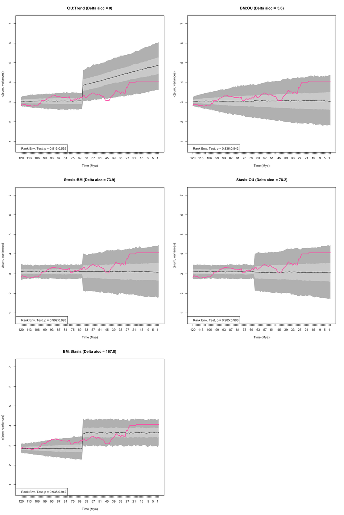

Empirical disparity through time (pink), simulate data based on estimated model parameters (grey), delta AICc, and range of p values from the Rank Envelope test for a variety of models with a shift in optima allowed at 66 Ma

```r
disp_time
```

```
##           aicc delta_aicc weight_aicc log.lik param ancestral state
## OU:Trend  -228        0.0       0.943   118.2     4           3.051
## BM:OU     -222        5.6       0.057   115.4     4           3.052
## Stasis:BM -154       73.9       0.000    80.2     3              NA
## Stasis:OU -150       78.2       0.000    80.2     5              NA
## BM:Stasis  -60      167.8       0.000    34.3     4           2.858
##           sigma squared alpha optima.1 theta.1 omega trend median p value
## OU:Trend          0.003 0.039       NA      NA    NA 0.015      0.5264735
## BM:OU             0.003 0.000    4.055      NA    NA    NA      0.8391608
## Stasis:BM         0.004    NA       NA   3.109 0.025    NA      0.9925075
## Stasis:OU         0.004 0.000    4.055   3.109 0.025    NA      0.9865135
## BM:Stasis         0.002    NA       NA   3.648 0.113    NA      0.9385614
##           lower p value upper p value
## OU:Trend      0.5134865     0.5394605
## BM:OU         0.8361638     0.8421578
## Stasis:BM     0.9920080     0.9930070
## Stasis:OU     0.9850150     0.9880120
## BM:Stasis     0.9350649     0.9420579
```

## `model.test.sim`

Note that all the models above where run using the `model.test.wrapper` function that is a… wrapping function! In practice, this function runs two main functions from the `dispRity` package and then plots the results:

- `model.test` and
- `model.test.sim`

The `model.test.sim` allows to simulate disparity evolution given a `dispRity` object input (as in `model.test.wrapper`) or given a model and its specification. For example, it is possible to simulate a simple Brownian motion model (or any of the other models or models combination described above):

```r
## A simple BM model
model_simulation <- model.test.sim(sim = 1000, model = "BM", time.span = 50, variance = 0.1,
                                   sample.size = 100, parameters = list(ancestral.state = 0))
model_simulation
```

```
## Disparity evolution model simulation:
## Call: model.test.sim(sim = 1000, model = "BM", time.span = 50, variance = 0.1, sample.size = 100, parameters = list(ancestral.state = 0))
##
## Model simulated (1000 times):
## [1] "BM"
```

This will simulate 1000 Brownian motions for 50 units of time with 100 sampled elements, a variance of 0.1 and an ancestral state of 0. We can also pass multiple models in the same way we did it for `model.test` This model can then be summarised and plotted as most `dispRity` objects:

```r
## Displaying the 5 first rows of the summary
head(summary(model_simulation))
```

```
##   subsets   n var       median      2.5%       25%       75%    97.5%
## 1      50 100 0.1  0.028813549 -1.982347 -0.695173 0.6642479 2.049684
## 2      49 100 0.1 -0.025852514 -2.799055 -1.011667 0.9802063 2.709871
## 3      48 100 0.1 -0.031131199 -3.507178 -1.270334 1.2187371 3.380295
## 4      47 100 0.1 -0.007009638 -3.990968 -1.355371 1.3982404 3.881421
## 5      46 100 0.1  0.062447620 -4.548205 -1.529046 1.6154340 4.168885
## 6      45 100 0.1  0.091265428 -4.756955 -1.624929 1.7097088 4.754084
```

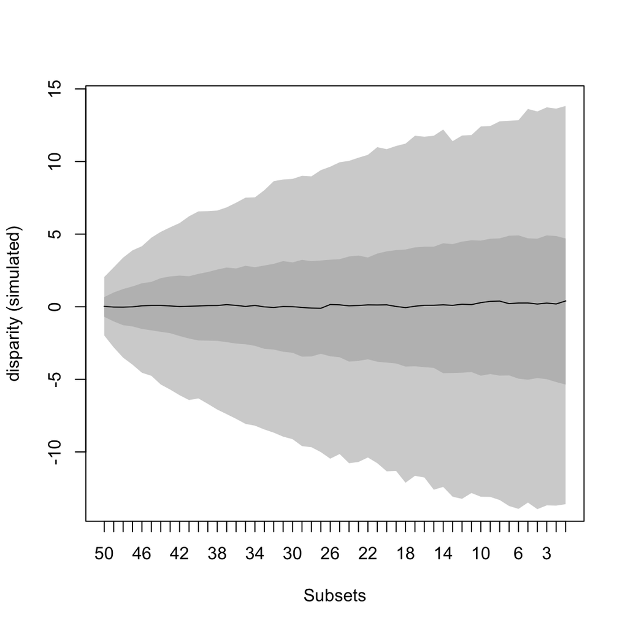

A simulated Brownian motion

```r
## Plotting the simulations
plot(model_simulation)
```

Note that these functions can take all the arguments that can be passed to `plot`, `summary`, `plot.dispRity` and `summary.dispRity`.

### Simulating tested models

Maybe more interestingly though, it is possible to pass the output of `model.test` directly to `model.test.sim` to simulate the models that fits the data the best and calculate the Rank Envelope test *p* value. Let’s see that using the simple example from the start:

```r
## Fitting multiple models on the data set
disp_time <- model.test(data = model_data, model = c("Stasis", "BM", "OU", "Trend", "EB"))
```

```
## Evidence of equal variance (Bartlett's test of equal variances p = 0).
## Variance is not pooled.
## Running Stasis model...Done. Log-likelihood = -59.501
## Running BM model...Done. Log-likelihood = 123.938
## Running OU model...Done. Log-likelihood = 126.431
## Running Trend model...Done. Log-likelihood = 126.361
## Running EB model...Done. Log-likelihood = 113.081
```

```r
summary(disp_time)
```

```
##        aicc delta_aicc weight_aicc log.lik param theta.1 omega
## Stasis  123      369.6       0.000   -59.5     2   3.403  0.15
## BM     -244        2.7       0.157   123.9     2      NA    NA
## OU     -245        2.0       0.227   126.4     4      NA    NA
## Trend  -247        0.0       0.617   126.4     3      NA    NA
## EB     -220       26.6       0.000   113.1     3      NA    NA
##        ancestral state sigma squared alpha optima.1 trend     eb
## Stasis              NA            NA    NA       NA    NA     NA
## BM               2.858         0.003    NA       NA    NA     NA
## OU               2.835         0.002 0.004    5.707    NA     NA
## Trend            2.839         0.002    NA       NA  0.01     NA
## EB               4.055         0.002    NA       NA    NA -0.014
```

As seen before, the Trend model fitted this dataset the best. To simulate what 1000 Trend models would look like using the same parameters as the ones estimated with `model.test` (here the ancestral state being 2.839, the sigma squared beeing 0.002 and the trend of 0.01), we can simply pass this model to `model.test.sim`:

```r
## Simulating 1000 Trend model with the observed parameters
sim_trend <- model.test.sim(sim = 1000, model = disp_time)
sim_trend
```

```
## Disparity evolution model simulation:
## Call: model.test.sim(sim = 1000, model = disp_time)
##
## Model simulated (1000 times):
##       aicc log.lik param ancestral state sigma squared trend
## Trend -247   126.4     3           2.839         0.002  0.01
##
## Rank envelope test
##  p-value of the test: 0.986014 (ties method: midrank)
##  p-interval         : (0.986014, 0.986014)
```

By default, the model simulated is the one with the lowest AICc (`model.rank = 1`) but it is possible to choose any ranked model, for example, the OU (second one):

```r
## Simulating 1000 OU model with the observed parameters
sim_OU <- model.test.sim(sim = 1000, model = disp_time, model.rank = 2)
sim_OU
```

```
## Disparity evolution model simulation:
## Call: model.test.sim(sim = 1000, model = disp_time, model.rank = 2)
##
## Model simulated (1000 times):
##    aicc log.lik param ancestral state sigma squared alpha optima.1
## OU -245   126.4     4           2.835         0.002 0.004    5.707
##
## Rank envelope test
##  p-value of the test: 0.8646354 (ties method: midrank)
##  p-interval         : (0.8641359, 0.8651349)
```

And as the example above, the simulated data can be plotted or summarised:

```r
head(summary(sim_trend))
```

```
##   subsets n        var   median     2.5%      25%      75%    97.5%
## 1     120 5 0.06056490 2.838061 2.626191 2.764922 2.914053 3.072828
## 2     119 5 0.07453663 2.849184 2.599005 2.767842 2.944862 3.114740
## 3     118 6 0.07556947 2.858759 2.627789 2.771548 2.952593 3.133740
## 4     117 6 0.07556947 2.870387 2.594052 2.776101 2.960277 3.126975
## 5     116 6 0.07556947 2.875481 2.579568 2.775944 2.987146 3.188655
## 6     115 7 0.06590243 2.899882 2.599756 2.798555 2.989515 3.174047
```

```r
head(summary(sim_OU))
```

```
##   subsets n        var   median     2.5%      25%      75%    97.5%
## 1     120 5 0.06056490 2.829252 2.616057 2.754862 2.903403 3.039918
## 2     119 5 0.07453663 2.849594 2.601959 2.758069 2.934439 3.113213
## 3     118 6 0.07556947 2.861249 2.604016 2.762618 2.957195 3.141581
## 4     117 6 0.07556947 2.873831 2.605468 2.786999 2.971392 3.139529
## 5     116 6 0.07556947 2.881768 2.576742 2.783911 2.985948 3.164698
## 6     115 7 0.06590243 2.905404 2.614954 2.796941 2.997537 3.181481
```

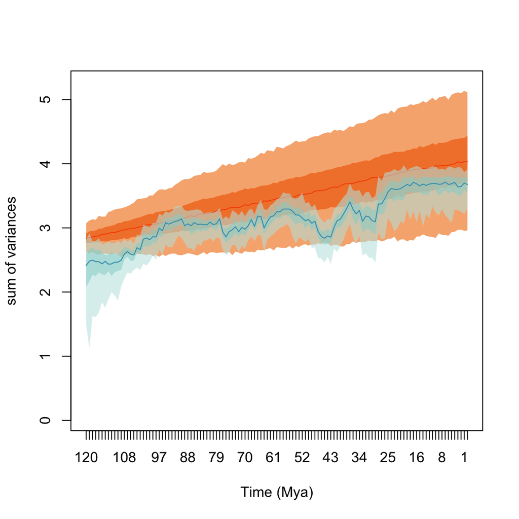

The best fitted model (Trend) and the observed disparity through time

```r
## The trend model with some graphical options
plot(sim_trend, xlab = "Time (Mya)", ylab = "sum of variances",
    col = c("#F65205", "#F38336", "#F7B27E"))

## Adding the observed disparity through time
plot(model_data, add = TRUE, col = c("#3E9CBA", "#98D4CF90", "#BFE4E390"))
```

# References

Beck, Robin M, and Michael S Lee. 2014. “Ancient Dates or Accelerated Rates? Morphological Clocks and the Antiquity of Placental Mammals.” *Proceedings of the Royal Society B: Biological Sciences* 281 (20141278): 1–10. doi:10.1098/rspb.2014.1278.

Guillerme, Thomas. 2018. “dispRity: A Modular R Package for Measuring Disparity.” *Methods in Ecology and Evolution* 9 (7). Wiley Online Library: 1755–63. https://doi.org/10.1111/2041-210X.13022.

Hunt, Gene. 2006. “Fitting and Comparing Models of Phyletic Evolution: Random Walks and Beyond.” *Paleobiology* 32 (4). Cambridge University Press: 578–601. https://doi.org/10.1666/05070.1.

———. 2012. “Measuring Rates of Phenotypic Evolution and the Inseparability of Tempo and Mode.” *Paleobiology* 38 (3). GeoScienceWorld: 351–73. https://doi.org/10.1666/11047.1.

Hunt, Gene, Melanie J Hopkins, and Scott Lidgard. 2015. “Simple Versus Complex Models of Trait Evolution and Stasis as a Response to Environmental Change.” *Proceedings of the National Academy of Sciences*. National Acad Sciences, 201403662. https://doi.org/10.1073/pnas.1403662111.

Murrell, David J. 2018. “A Global Envelope Test to Detect Non-Random Bursts of Trait Evolution.” *Methods in Ecology and Evolution* 9 (7). Wiley Online Library: 1739–48. https://doi.org/10.1111/2041-210X.13006.